# **Mental Health of College Students**

Eric Tran

## **INTRODUCTION**

Mental health is an uncomfortable subject that many people refuse to talk about openly. But recently, the topic of mental health has become increasingly relevant. The discussion surrounding mental well-being has shifted, and policy makers, educators, and the general public are beginning to recognize the importance of encouraging mental health awareness. One of the most concerning discussions about mental health is its affect on students. Especially college students.

As many college students are aware, college is not easy! The pressures associated with higher education can take a toll on one's mental well-being, leading to stress, anxiety, and depression. In fact, many of us know friends or peers who struggle with mental health issues, or perhaps have experienced these challenges ourselves. Tragically, some of us may have even experienced the extremely difficult situation of losing a friend to mental health. The most challenging thing about mental health is that it often times goes unnoticed.

In this analysis, I will explore the connection between college students and their self-reported depression. By exploring this relationship, I hope to find indicators that could help identify those who may be suffering from mental health challenges before it's too late.

## **PART 1: DATA COLLECTION**

### **Obtaining the data**

Before we work on our data, we should import useful libraries that will ease our work.\ Here are the links to the API's of the libraries I will be using:

$\;\;\;\;\;\;$ Numpy: https://numpy.org/doc/stable/reference/ $\;\;\;\;\;\;$ Pandas: https://pandas.pydata.org/docs/reference/index.html $\;\;\;\;\;\;$ Sklearn: https://scikit-learn.org/stable/modules/classes.html $\;\;\;\;\;\;$ Matplotlib: https://matplotlib.org/stable/api/index.html $\;\;\;\;\;\;$ Seaborn: https://seaborn.pydata.org/api.html

These API's will provide you with useful documentation for functions we will be using in this project!

```python
import numpy as np # for math and computation
import pandas as pd # for manipulation of data and dataframes
import sklearn # for useful machine learning functionality
from sklearn.preprocessing import OneHotEncoder
import matplotlib.pyplot as plt # for visualization of our data
import seaborn as sns # another visualization library
pd.options.mode.chained_assignment = None  # turn off pandas copy warnings
```

```python
df = pd.read_csv('mentalhealth.csv')
df
```

|  | Timestamp | Choose your gender | Age | What is your course? | Your current year of Study | What is your CGPA? | Marital status | Do you have Depression? | Do you have Anxiety? | Do you have Panic attack? | Did you seek any specialist for a treatment? |
| --- | --- | --- | --- | --- | --- | --- | --- | --- | --- | --- | --- |
| 0 | 8/7/2020 12:02 | Female | 18.0 | Engineering | year 1 | 3.00 - 3.49 | No | Yes | No | Yes | No |
| 1 | 8/7/2020 12:04 | Male | 21.0 | Islamic education | year 2 | 3.00 - 3.49 | No | No | Yes | No | No |
| 2 | 8/7/2020 12:05 | Male | 19.0 | BIT | Year 1 | 3.00 - 3.49 | No | Yes | Yes | Yes | No |
| 3 | 8/7/2020 12:06 | Female | 22.0 | Laws | year 3 | 3.00 - 3.49 | Yes | Yes | No | No | No |
| 4 | 8/7/2020 12:13 | Male | 23.0 | Mathemathics | year 4 | 3.00 - 3.49 | No | No | No | No | No |
| ... | ... | ... | ... | ... | ... | ... | ... | ... | ... | ... | ... |
| 96 | 13/07/2020 19:56:49 | Female | 21.0 | BCS | year 1 | 3.50 - 4.00 | No | No | Yes | No | No |
| 97 | 13/07/2020 21:21:42 | Male | 18.0 | Engineering | Year 2 | 3.00 - 3.49 | No | Yes | Yes | No | No |
| 98 | 13/07/2020 21:22:56 | Female | 19.0 | Nursing | Year 3 | 3.50 - 4.00 | Yes | Yes | No | Yes | No |
| 99 | 13/07/2020 21:23:57 | Female | 23.0 | Pendidikan Islam | year 4 | 3.50 - 4.00 | No | No | No | No | No |
| 100 | 18/07/2020 20:16:21 | Male | 20.0 | Biomedical science | Year 2 | 3.00 - 3.49 | No | No | No | No | No |

101 rows × 11 columns

I sourced the dataset for this analysis from Kaggle and downloaded it in CSV format. You can access the dataset at the following URL: \ \ $\;\;\;\;\;\;$ https://www.kaggle.com/datasets/shariful07/student-mental-health?resource=download \ \ In order to see our data and convert it to a dataframe, I make use of Pandas. Using Pandas' read_csv function we are able to convert the CSV file into a Pandas DataFrame, making it easier to manipulate and analyze the data. From here we can extract some information.

This dataset provides a range of indicators that will serve as the foundation for our analysis. Specifically, I aim to explore how certain characteristics – gender, age, major, academic year, GPA, marital status, anxiety, and panic attacks – may be associated with depression in a particular college student.

## **PART 2: DATA PROCESSING**

### **Cleaning the Data**

Our analysis aims to uncover potential relationships between specific characteristics of college students and their connection to mental health. In particular, we are interested in exploring the association with depression. To ensure the correctness of our analysis, we will organize and extract useful information from our data, and "clean" it to remove any inconsistencies or unhelpful information before proceeding with our analysis.

```python
df.shape
```

```
(101, 11)
```

```python
df.columns
```

```
Index(['Timestamp', 'Choose your gender', 'Age', 'What is your course?',
       'Your current year of Study', 'What is your CGPA?', 'Marital status',
       'Do you have Depression?', 'Do you have Anxiety?',
       'Do you have Panic attack?',
       'Did you seek any specialist for a treatment?'],
      dtype='object')
```

```python
# remove timestamp and professional help column
df = df.drop('Timestamp', axis = 1)
df = df.drop('Did you seek any specialist for a treatment?', axis = 1)

# rename columns
new_columns = ['gender', 'age', 'major', 'year_level', 'gpa', 'marital_status',
               'depression', 'anxiety', 'panic_attack']
df.columns = new_columns

# reorganize columns
df = df[['gender', 'age', 'major', 'year_level', 'gpa', 'marital_status',
                'anxiety', 'panic_attack', 'depression']]
df
```

|  | gender | age | major | year_level | gpa | marital_status | anxiety | panic_attack | depression |
| --- | --- | --- | --- | --- | --- | --- | --- | --- | --- |
| 0 | Female | 18.0 | Engineering | year 1 | 3.00 - 3.49 | No | No | Yes | Yes |
| 1 | Male | 21.0 | Islamic education | year 2 | 3.00 - 3.49 | No | Yes | No | No |
| 2 | Male | 19.0 | BIT | Year 1 | 3.00 - 3.49 | No | Yes | Yes | Yes |
| 3 | Female | 22.0 | Laws | year 3 | 3.00 - 3.49 | Yes | No | No | Yes |
| 4 | Male | 23.0 | Mathemathics | year 4 | 3.00 - 3.49 | No | No | No | No |
| ... | ... | ... | ... | ... | ... | ... | ... | ... | ... |
| 96 | Female | 21.0 | BCS | year 1 | 3.50 - 4.00 | No | Yes | No | No |
| 97 | Male | 18.0 | Engineering | Year 2 | 3.00 - 3.49 | No | Yes | No | Yes |
| 98 | Female | 19.0 | Nursing | Year 3 | 3.50 - 4.00 | Yes | No | Yes | Yes |
| 99 | Female | 23.0 | Pendidikan Islam | year 4 | 3.50 - 4.00 | No | No | No | No |
| 100 | Male | 20.0 | Biomedical science | Year 2 | 3.00 - 3.49 | No | No | No | No |

101 rows × 9 columns

Before any changes were made, our data had 101 observations and 11 columns. I removed the "Timestamp" column from the dataset since knowing when a student submitted their survey is not important to us, I also removed the "Did you seek any specialist for a treatment?" column since we are looking at self-reported instances of mental health. After this, I renamed and reordered the columns for simplicity. Now the data has 9 columns.

Then we check if our dataset has any missing data within our observations. To do so, we check the sum of null items within the columns. We see that there is 1 piece of missing data within the age column of our dataset.

```python
df.isnull().sum() # check for any null values
```

```
gender            0
age               1
major             0
year_level        0
gpa               0
marital_status    0
anxiety           0
panic_attack      0
depression        0
dtype: int64
```

Now we must determine how we should handle this missing data. There are a few ways we can compensate for this data, we could try different methods of imputation such as mean imputation where we give this observation's age as the average of all ages in our dataset, or we could do Hot-Deck imputation by giving the neighboring observation's age as compensation. I will choose to simply drop the observation since there is only one.

```python
df = df.dropna(how='any',axis=0) # drop null values
df.isnull().sum() # check for any null values again
```

```
gender            0
age               0
major             0
year_level        0
gpa               0
marital_status    0
anxiety           0
panic_attack      0
depression        0
dtype: int64
```

```python
df.shape
```

```
(100, 9)
```

We now must check for inconsistencies within our data. Such data can lead to unreliable and meaningless information. One common type of inconsistency arises when the same information is represented in different ways. For instance, the values 3 and 3.0 are numerically equivalent but may be interpreted as different by our dataframe. It is important that we go through our data to make sure that such inconsistencies do not affect our analysis.

```python
df.nunique()
```

```
gender             2
age                7
major             49
year_level         7
gpa                6
marital_status     2
anxiety            2
panic_attack       2
depression         2
dtype: int64
```

```python
# this for loop will go through
for col in df.columns:
     print(f"Unique items in column '{col}':")
     print(df[col].unique())
```

```
Unique items in column 'gender':
['Female' 'Male']
Unique items in column 'age':
[18. 21. 19. 22. 23. 20. 24.]
Unique items in column 'major':
['Engineering' 'Islamic education' 'BIT' 'Laws' 'Mathemathics'
 'Pendidikan islam' 'BCS' 'Human Resources' 'Irkhs' 'Psychology' 'KENMS'
 'Accounting ' 'ENM' 'Marine science' 'KOE' 'Banking Studies'
 'Business Administration' 'Law' 'KIRKHS' 'Usuluddin ' 'TAASL' 'Engine'
 'ALA' 'Biomedical science' 'koe' 'Kirkhs' 'BENL' 'Benl' 'IT' 'CTS'
 'engin' 'Econs' 'MHSC' 'Malcom' 'Kop' 'Human Sciences ' 'Biotechnology'
 'Communication ' 'Diploma Nursing' 'Pendidikan Islam ' 'Radiography'
 'psychology' 'Fiqh fatwa ' 'DIPLOMA TESL' 'Koe' 'Fiqh'
 'Islamic Education' 'Nursing ' 'Pendidikan Islam']
Unique items in column 'year_level':
['year 1' 'year 2' 'Year 1' 'year 3' 'year 4' 'Year 2' 'Year 3']
Unique items in column 'gpa':
['3.00 - 3.49' '3.50 - 4.00' '3.50 - 4.00 ' '2.50 - 2.99' '2.00 - 2.49'
 '0 - 1.99']
Unique items in column 'marital_status':
['No' 'Yes']
Unique items in column 'anxiety':
['No' 'Yes']
Unique items in column 'panic_attack':
['Yes' 'No']
Unique items in column 'depression':
['Yes' 'No']
```

Ah Ha! We can observe that our data does indeed have inconsistencies! Take notice of the unique values within our 'year_level' and 'gpa' column. We must correct these columns so that 'year_level' only contains 4 unique values, and that 'gpa' only contains 5 unique values.

```python
# Fixing inconsistencies in GPA
df['gpa'] = df['gpa'].str.strip() # remove spaces at end

# Fixing inconsistencies in Year Level
df['year_level'] = df['year_level'].str.lower() # convert to lowercase
df.nunique()
```

```
gender             2
age                7
major             49
year_level         4
gpa                5
marital_status     2
anxiety            2
panic_attack       2
depression         2
dtype: int64
```

## **PART 2: DATA PROCESSING**

### **Data transformation**

Now that we have clean data, we want to run computations on it. But before we do that, we can observe that most of the data we recieved are not numerical. This makes it hard for us to actually do any computations on it. So, for ease computation and interpretation, we want to transform our data.

There are several ways we can transform our data such as standardization, normalization, and scaling. The end goal of transformation is to turn our data into a metric in which our computers can actually compute!

```python
df.dtypes # lists the types contain within the columns of our dataframe
```

```
gender             object
age               float64
major              object
year_level         object
gpa                object
marital_status     object
anxiety            object
panic_attack       object
depression         object
dtype: object
```

```python
# Binary encoding columns
mapping = {'Yes': 1, 'No': 0} # yes = 1, no = 0
bcols = ['marital_status','anxiety', 'panic_attack', 'depression'] # columns to be changed
for c in bcols:
    df[c] = df[c].map(mapping)

df['gender'] = df['gender'].map({'Male': 0, 'Female': 1}) # binary encode gender m = 0, f = 1

# Changing year column
df['year_level'] = df['year_level'].str.extract('(\d)').astype(int) # extract the number from year

# Giving major a number
# dictionary with major names as keys and unique id as value
major_to_int = {major: i+1 for i, major in enumerate(df['major'].unique())}
df['encoded_major'] = df['major'].map(major_to_int) # map it

# Centering GPA
def get_midpoint(gpa):
    gpa = gpa.replace(' ', '').split('-') # retrieve float numbers from the string
    lower, upper = map(float, gpa) # get upper and lower bounds of the gpa range
    return (lower + upper) / 2

df['gpa_midpoint'] = df['gpa'].apply(get_midpoint) # apply our midpoint function to all gpa values and replace

df = df[['gender', 'age', 'major','encoded_major', 'year_level', 'gpa', 'gpa_midpoint','marital_status',
                'anxiety', 'panic_attack', 'depression']]
df
```

|  | gender | age | major | encoded_major | year_level | gpa | gpa_midpoint | marital_status | anxiety | panic_attack | depression |
| --- | --- | --- | --- | --- | --- | --- | --- | --- | --- | --- | --- |
| 0 | 1 | 18.0 | Engineering | 1 | 1 | 3.00 - 3.49 | 3.245 | 0 | 0 | 1 | 1 |
| 1 | 0 | 21.0 | Islamic education | 2 | 2 | 3.00 - 3.49 | 3.245 | 0 | 1 | 0 | 0 |
| 2 | 0 | 19.0 | BIT | 3 | 1 | 3.00 - 3.49 | 3.245 | 0 | 1 | 1 | 1 |
| 3 | 1 | 22.0 | Laws | 4 | 3 | 3.00 - 3.49 | 3.245 | 1 | 0 | 0 | 1 |
| 4 | 0 | 23.0 | Mathemathics | 5 | 4 | 3.00 - 3.49 | 3.245 | 0 | 0 | 0 | 0 |
| ... | ... | ... | ... | ... | ... | ... | ... | ... | ... | ... | ... |
| 96 | 1 | 21.0 | BCS | 7 | 1 | 3.50 - 4.00 | 3.750 | 0 | 1 | 0 | 0 |
| 97 | 0 | 18.0 | Engineering | 1 | 2 | 3.00 - 3.49 | 3.245 | 0 | 1 | 0 | 1 |
| 98 | 1 | 19.0 | Nursing | 48 | 3 | 3.50 - 4.00 | 3.750 | 1 | 0 | 1 | 1 |
| 99 | 1 | 23.0 | Pendidikan Islam | 49 | 4 | 3.50 - 4.00 | 3.750 | 0 | 0 | 0 | 0 |
| 100 | 0 | 20.0 | Biomedical science | 24 | 2 | 3.00 - 3.49 | 3.245 | 0 | 0 | 0 | 0 |

100 rows × 11 columns

We can notice that we must transform all columns except 'age' since it is already in a numerical format. We can also notice that the columns: 'marital_status','anxiety', 'panic_attack', and 'depression' are in the format of 'yes' and 'no'. So this means that we can transform them all in the same manner.

\ In order to transform yes and no answers, we do something called "Binary Encoding." This will simply give 'yes' the value of 1 and 'no' the value of 0. The column of 'gender' is also transformed using "Binary Encoding" since only two unqiue gender options are reported in this dataset: 0 = male, 1 = female.

\ The 'year_level' column can be intuitively transformed by simply using 1,2,3,4 respectively.

\ The 'major' column has 49 unique majors. One approach to transform our data, we can do something similar to "Binary Encoding" called "Hot-One Encoding." "Hot-One Encoding" will give categorical values a binary vector of n-length, where n = number of unique values. For example, red = [0,0,1], blue = [0,1,0], and green = [1,0,0]. If you are still confused here is a helpful article that describes why we do 'Hot-One Encoding': https://machinelearningmastery.com/why-one-hot-encode-data-in-machine-learning/. But the much simplier approach can be to just assign our majors an id between 1-49. We will place its encoding in a seperate column.

\ Finally, we must find a way to transform our 'gpa' column. GPA's are represented as a range of values which could make it difficult to make it into 1 value. Since there are 5 unique values, we could go with the same approach of "Hot-One encoding" but I simply chose to represent our GPAs as the center value of its range.

## **PART 3: DATA EXPLORATION**

It is important we get an understanding of our data and identify any trends which are present. To do this we can visualize it on plots and graphs making use of Matplotlib or Seaborn.

```python
df.describe()
```

|  | gender | age | encoded_major | year_level | gpa_midpoint | marital_status | anxiety | panic_attack | depression |
| --- | --- | --- | --- | --- | --- | --- | --- | --- | --- |
| count | 100.000000 | 100.00000 | 100.000000 | 100.000000 | 100.000000 | 100.000000 | 100.000000 | 100.000000 | 100.000000 |
| mean | 0.750000 | 20.53000 | 15.960000 | 1.980000 | 3.379900 | 0.160000 | 0.340000 | 0.330000 | 0.350000 |
| std | 0.435194 | 2.49628 | 14.657656 | 0.994734 | 0.537567 | 0.368453 | 0.476095 | 0.472582 | 0.479372 |
| min | 0.000000 | 18.00000 | 1.000000 | 1.000000 | 0.995000 | 0.000000 | 0.000000 | 0.000000 | 0.000000 |
| 25% | 0.750000 | 18.00000 | 3.000000 | 1.000000 | 3.245000 | 0.000000 | 0.000000 | 0.000000 | 0.000000 |
| 50% | 1.000000 | 19.00000 | 8.500000 | 2.000000 | 3.245000 | 0.000000 | 0.000000 | 0.000000 | 0.000000 |
| 75% | 1.000000 | 23.00000 | 26.250000 | 3.000000 | 3.750000 | 0.000000 | 1.000000 | 1.000000 | 1.000000 |
| max | 1.000000 | 24.00000 | 49.000000 | 4.000000 | 3.750000 | 1.000000 | 1.000000 | 1.000000 | 1.000000 |

The table above shows us some important information about the data contained in our dataset. From this we can observe a couple things. The average age of our students is 20.53 years old with the oldest students being 24 years old and the youngest being 18. Let's begin by exploring the affect of age.

### **Age**

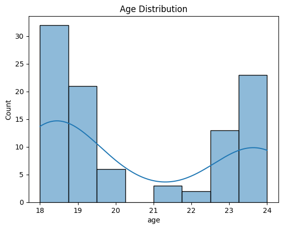

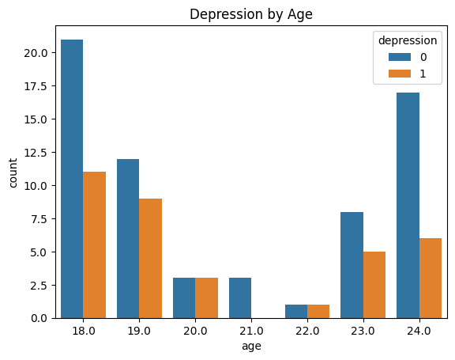

```python
# histogram showing the districution of age within our dataset
sns.histplot(data=df, x='age', kde=True)
plt.title('Age Distribution')
plt.show()

# a plot showing the count of every age who reported having depression or not
sns.countplot(data=df, x='age', hue='depression')
plt.title('Depression by Age')
plt.show()
```

From this we can see that the distribution of age is concentrated at the ends. This means that 18 year olds took this survey at the highest rate with 24 year olds coming in second. But even so, if we take a look at our count plot "Depression by Age", we can see that a 18 year olds have the highest count for self diagnosed depression, with 19 year olds close behind. The rate of depression among 19 year olds is interesting since the rate of their response was behind 24 year olds, but their rate of depression is higher.

\ Could the the fact that 18-19 year olds having depression be linked to the fact that these are the ages in which they are just starting college? Let's take a look at year level...

### **Year Level**

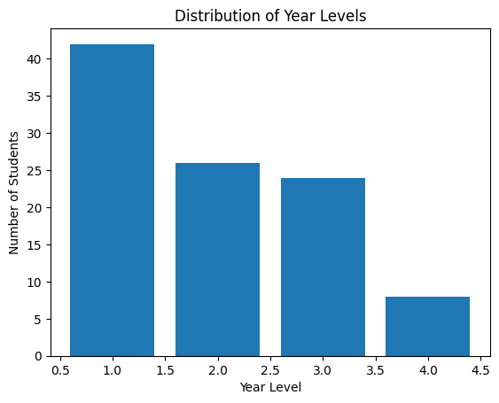

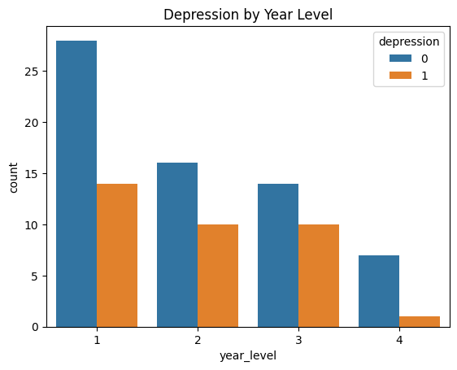

```python
# Histogram showing the distribution of age within our dataset
year_level_counts = df['year_level'].value_counts() # Count instances of each year level
plt.bar(year_level_counts.index, year_level_counts.values)

plt.xlabel('Year Level')
plt.ylabel('Number of Students')
plt.title('Distribution of Year Levels')
plt.show()

# a plot showing the count of every age who reported having depression or not
sns.countplot(data=df, x='year_level', hue='depression')
plt.title('Depression by Year Level')
plt.show()
```

We can see that depression does indeed have a downward trend as we move up in year with first years having the highest number of reported depression and fourth years having the lowest amount. But it is also important to realize that the proportion of answers of each year is not the same. We have a significantly larger number of students belonging in first year answering our survey than those from other years. Maybe we should take a look at the proportion of those who report depression among each year instead of simply a count.

```python
proportions = {}
for year in range(1, 5):
    # Obtain students at specific year
    year_students = df[df['year_level'] == year]

    num_depressed = year_students[year_students['depression'] == 1].shape[0] # number depressed in year
    total_year = year_students.shape[0] # total in year

    # Calculate the proportion
    proportion_depressed = num_depressed / total_year

    # Store the result in the dictionary
    proportions[year] = proportion_depressed

for year, proportion in proportions.items():
    print(f"Proportion of year {year} students who reported depression: {proportion}")
    print('\n')

# Calculating total population proportion
num_depressed = df[df['depression'] == 1].shape[0] # number of depressed in population
total_population = df.shape[0]
proportion_population = num_depressed / total_population
print(f"Proportion of all students who reported depression: {proportion_population}")
```

```
Proportion of year 1 students who reported depression: 0.3333333333333333


Proportion of year 2 students who reported depression: 0.38461538461538464


Proportion of year 3 students who reported depression: 0.4166666666666667


Proportion of year 4 students who reported depression: 0.125


Proportion of all students who reported depression: 0.35
```

From this we see that although first years had the most reports of depression, third years have higher proportion of students with depression compared to any other year. But the proportions of years 1-3 do not vary much from the overall proportion of .35. Fourth years however, still maintain the lowest number of reports and proportion to the rest of the year levels. This may be the result of so few observations.

\ Since our plot reveals that the proportion of depression among students is relatively consistent across different year levels, with the exception of fourth years, this suggests that year level may not be as influential a factor in student depression as I initially believed. But one thing that all students share in common is having to maintain a GPA, let's take a look at how GPA is distributed in our data

### **GPA**

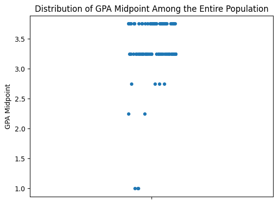

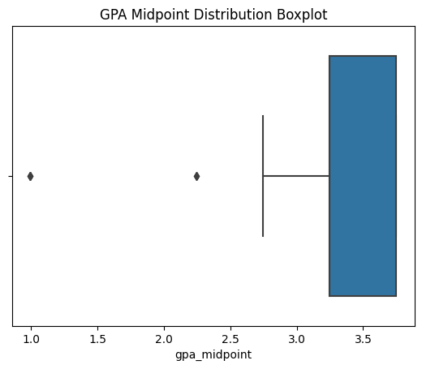

```python
sns.stripplot(data=df, y='gpa_midpoint')
plt.ylabel('GPA Midpoint')
plt.title('Distribution of GPA Midpoint Among the Entire Population')
plt.show()

sns.boxplot(data=df, x='gpa_midpoint')
plt.title('GPA Midpoint Distribution Boxplot')
plt.show()
```

First we can demonstrate the distribution of GPA among our students as a simple jitter plot. This plot simply places a point at the respective midpoint when there is an instance within the population. But, it is hard to see since we have so many observations! In order to extract more information we can employ boxplots.

\ Using boxplots, we can see the distribution of GPA among our entire population more clearly and with some extra information! Our dataset contains a few outliers at approximately 1.0 and 2.3, this means that these points of data are unusually different than the rest of the population. Remember that we are actually using the midpoint of our GPA range, this means that a majority of our students have a GPA in the ranges [3.0 - 3.49] and [3.5 - 4.0].

\ If you are having trouble understanding boxplots, here is a good and simple article which can help you get started!: https://datatab.net/tutorial/box-plot

\ Let's also create a boxplot for the distribution of GPA among year levels.

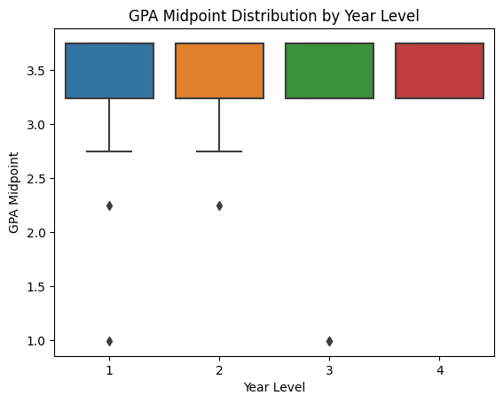

```python
sns.boxplot(data=df, x='year_level', y='gpa_midpoint')
plt.xlabel('Year Level')
plt.ylabel('GPA Midpoint')
plt.title('GPA Midpoint Distribution by Year Level')
```

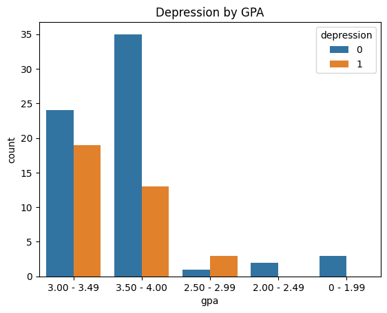

```python
sns.countplot(data=df, x='gpa', hue='depression')
plt.title('Depression by GPA')
plt.show()
```

### **Martial Status**

One of the more interesting features described within our dataset is the martial status. First lets see how many of our students are married or single and its relation to depression rates...

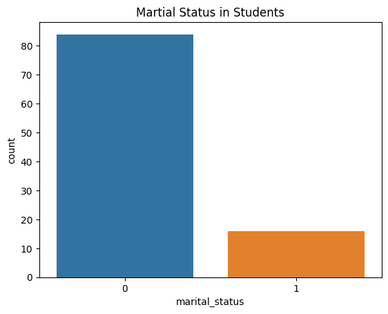

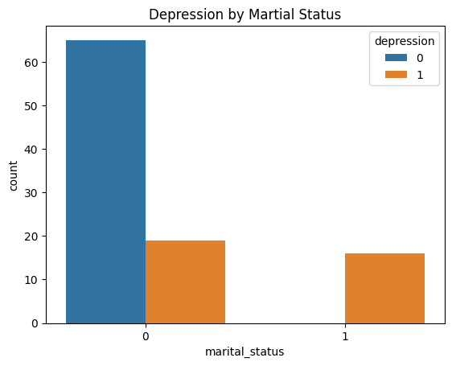

```python
sns.countplot(data=df, x='marital_status')
plt.title('Martial Status in Students')
plt.show()

sns.countplot(data=df, x='marital_status', hue='depression')
plt.title('Depression by Martial Status')
plt.show()
```

```python
print(df['marital_status'].value_counts()[0])
print(df['marital_status'].value_counts()[1])
```

```
84
16
```

A significant majority of our students are not married, specifcally 84/100 students are single while 16/100 are married. While single students reported more instances of depression than married students, 100% of students who were married reported depression! Martial status may play an important role in determining whether a student is more likely to develop depression.

### **Gender**

There have been many studies done about depression rates among men and women. John Hopkins Medicine states that women are actually twice as likely to develop depression than men (https://www.hopkinsmedicine.org/health/wellness-and-prevention/mental-health-disorder-statistics#:~:text=Women%20are%20nearly%20twice%20as,onset%20is%20the%20mid%2D20s)! Let's see if our data replicates the same trend...

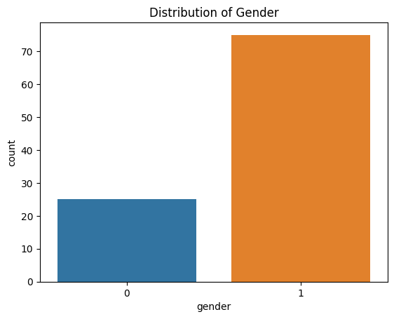

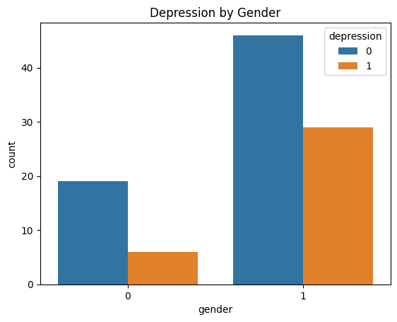

```python
sns.countplot(data=df, x='gender')
plt.title('Distribution of Gender')
plt.show()

sns.countplot(data=df, x='gender', hue='depression')
plt.title('Depression by Gender')
plt.show()
```

```python
# Calculating proportion
males_df = df[df['gender'] == 0] # get rows which are male
num_males = males_df.shape[0] # get total males
depressed_males = males_df[males_df['depression'] == 1].shape[0] # get number of males who are depressed
prop_m = depressed_males / num_males # calculate proportion

# Same thing but for females
females_df = df[df['gender'] == 1]
num_females = females_df.shape[0]
depressed_females = females_df[females_df['depression'] == 1].shape[0]
prop_f = depressed_females / num_females


print(prop_m)
print(prop_f)
```

```
0.24
0.38666666666666666
```

From our plot, we can see that female students not only experience depression at a higher frequency but also at a greater proportion of instances compared to male students. Recall that 0 = male and 1 = female due to binary encoding.

### **Anxiety and Panic Attacks**

Similar to gender, many studies have also been conducted on how other mental health disorders can affect depression. A study from NAMI states that "60% of those with anxiety will also have symptoms of depression" (https://www.nami.org/Blogs/NAMI-Blog/January-2018/The-Comorbidity-of-Anxiety-and-Depression#:~:text=Some%20estimates%20show%20that%2060,with%20depression%20also%20experiencing%20anxiety)

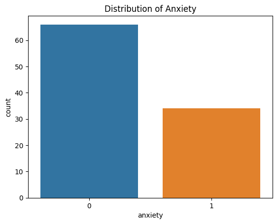

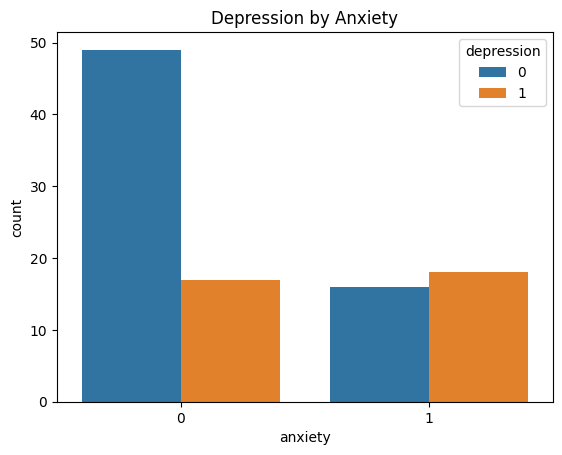

```python
sns.countplot(data=df, x='anxiety')
plt.title('Distribution of Anxiety')
plt.show()

sns.countplot(data=df, x='anxiety', hue='depression')
plt.title('Depression by Anxiety')
plt.show()
```

```python
# Calculate Anxiety proportions
anxiety_df = df[df['anxiety'] == 1] # get rows which have anxiety
num_anxiety = anxiety_df.shape[0] # get total anxiety observations
depressed_anxiety = anxiety_df[anxiety_df['depression'] == 1].shape[0] # get number of students w/ anxiety who are depressed
prop_a = depressed_anxiety / num_anxiety # calculate proportion

nanxiety_df = df[df['anxiety'] == 0] # get rows which have anxiety
num_nanxiety = nanxiety_df.shape[0] # get total anxiety observations
depressed_nanxiety = nanxiety_df[nanxiety_df['depression'] == 1].shape[0] # get number of students w/ anxiety who are depressed
prop_b = depressed_nanxiety / num_nanxiety # calculate proportion

print(prop_a)
print(prop_b)
```

```
0.5294117647058824
0.25757575757575757
```

We can see that over 52% of students who reported anxiety also reported depression. We can compare this to the around 25% of students who did not report anxiety but reported depression. Let's also observe how a history of panic attack can affect this trend.

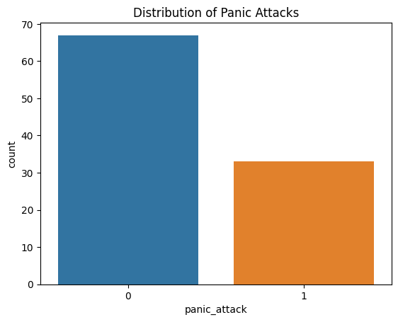

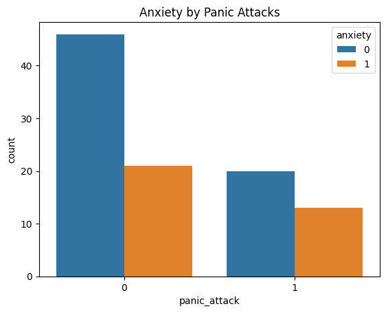

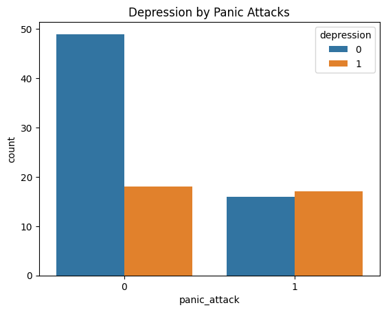

```python
sns.countplot(data=df, x='panic_attack')
plt.title('Distribution of Panic Attacks')
plt.show()

sns.countplot(data=df, x='panic_attack', hue='anxiety')
plt.title('Anxiety by Panic Attacks')
plt.show()

sns.countplot(data=df, x='panic_attack', hue='depression')
plt.title('Depression by Panic Attacks')
plt.show()
```

### **Major**

There is a common theory that students who are in a "harder" major experience depression at a much higher rate. These usually refer to majors belonging to the STEM field such as mathematics or engineering. Let's take a look at our data to see if this is true. First let's use a pie chart in order to see the distribution of majors among our dataset.

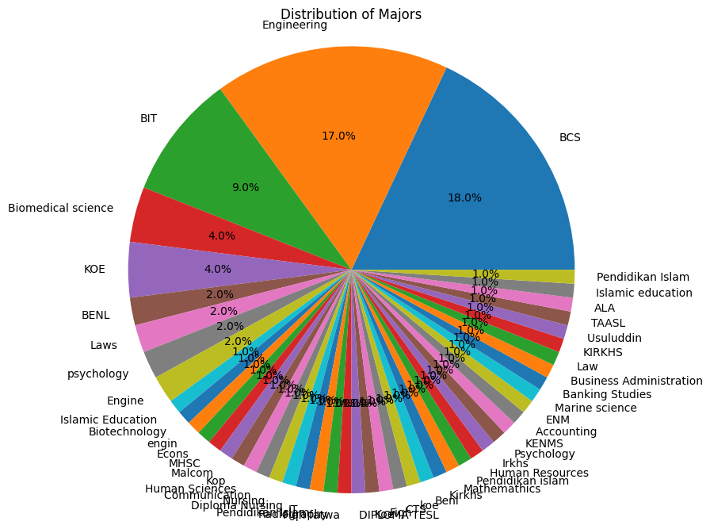

```python
# Occurences of each major
major_counts = df['major'].value_counts()

plt.figure(figsize=(8, 8))
plt.pie(major_counts, labels=major_counts.index, autopct='%1.1f%%')
plt.axis('equal')

plt.title('Distribution of Majors')
plt.show()
```

The most common major in our dataset was Bachelor in Computer Science (BCS), the second most common was Engineering, followed by Bachelor of Information Technology (BIT).

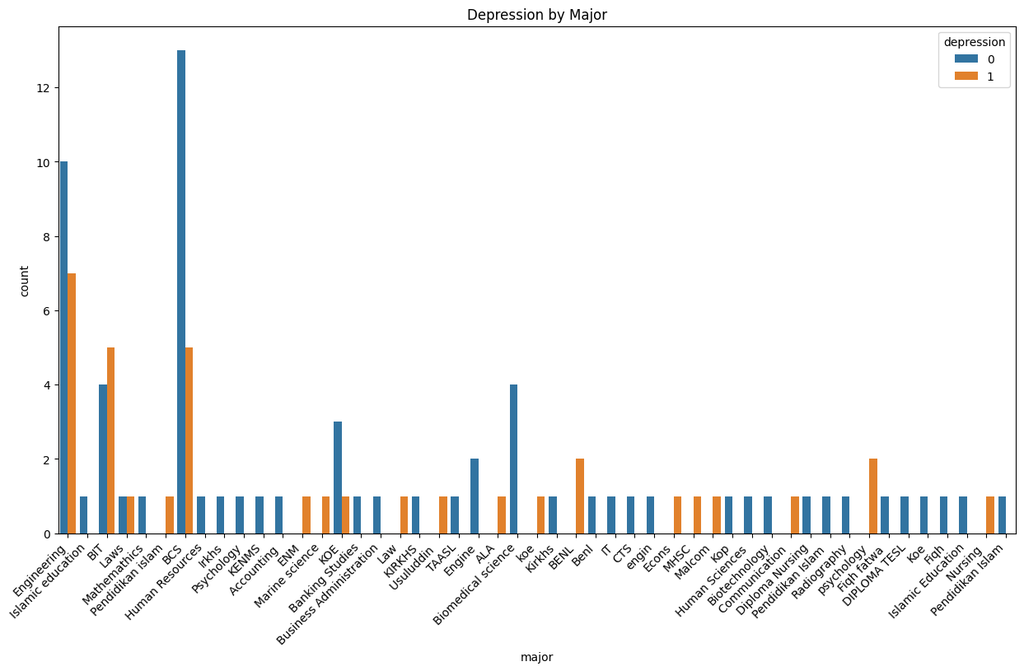

```python
plt.figure(figsize=(15, 8))
sns.countplot(data=df, x='major', hue='depression')
plt.title('Depression by Major')

plt.xticks(rotation=45, ha='right')  # rotate the x-axis labels
plt.show()
```

Similar to previous count plots we have seen, the plot above shows the ratio of students who reported having depression vs not having depression within each major. Unexceptedly, while having the most students belonging to the major, the BCS major has a very high ratio of students who reported not feeling depressed. Engineering however had a noticiably close ratio

## **PART 4: MACHINE LEARNING**

After carefully examining the relationships between various indicators in our data, we're now ready to move to the next step. Our end goal is to determine the likelihood of a student developing depression based on the factors we've identified in our data. So, how do we go about this?

Through Machine Learning! The Machine Learning process contains 3 essential parts: a hypothesis function which predicts an outcome, a loss function which calculates the error of prediction, and an optimization process which minimizes this "loss."

We want to use Machine Learning algorithms on our data in order to build a model which can calculate the probability of a student having depression based on the features we've analyzed. This is called a “Binary Classification Problem.” In Binary Classification, we aim to categorize data into one of two classes, for our specific analysis it would be whether a student has depression or not.

There are several Machine Learning algorithms which are designed to handle this task. I will demonstrate a few...

### **Logistic Regression**

Logistic regression is the first binary classification algorithm we will use. Given a linear equation representing an observation and consisting of features we possess, our linear regression model will use something called the "sigmoid function" to give us a number between 0 and 1 which will represent the probability of our observation belonging to one of the classes. Usually, we place a threshold of 0.5 to determine which class an observation belongs to.

In order to build an accurate model, we use known data to train our Logistic regression model in combination with a loss function (the Binary Cross Entropy function) and an optimization algorithm called Gradient Descent. Providing models with data to train is called "Supervised learning."

We can use the Sklearn library in order to do this:

```python
from sklearn.linear_model import LogisticRegression
from sklearn.model_selection import train_test_split
from sklearn.metrics import accuracy_score

X = ['gender', 'age', 'encoded_major', 'year_level', 'gpa_midpoint', 'marital_status', 'anxiety', 'panic_attack']
y = df['depression']

# split data
X = df[features]
y = df[target]
X_train, X_test, y_train, y_test = train_test_split(X, y)

# init regression model
model = LogisticRegression(max_iter=1000).fit(X_train, y_train)
y_pred = model.predict(X_test)

print("Logisitic Regression Accuracy:", accuracy_score(y_test, y_pred))

results_df = pd.DataFrame({'Actual': y_test, 'Predicted': y_pred})
print(results_df)
```

[output not shown]

In our code you can notice that we split our data. This is a "Validation." In Validation, we take our "training data", or the data we, and split it into two parts. One split is reserved to train the data as usual, but the other split is used to test our model in order to see how accurate it is.

Using Sklearn we can obtain an accuracy score of how well our model did at predicting whether or not a student reported depression. We had around an 0.80 accuracy rating!

### **Decision Tree & Random Forests**

Decision Trees are another method of classification in Machine Learning. It starts with a node and traverses down branches depending on the feature an observation possess. It continues down the tree until it reaches a label which the observation is then classified as. It is basically asks a bunch of yes or no answers until it can come up with a conclusion on what the observation is!

Again, we use Sklearn to implement this algorithm onto our data:

```python
from sklearn.tree import DecisionTreeClassifier

X = df[['gender', 'age', 'encoded_major', 'year_level', 'gpa_midpoint', 'marital_status', 'anxiety', 'panic_attack']]
y = df['depression']

# Split data
X_train, X_test, y_train, y_test = train_test_split(X, y)

# Create and fit the decision tree mdel
dt = DecisionTreeClassifier().fit(X_train, y_train)
y_pred = dt.predict(X_test)

print("Decision Tree Accuracy:", accuracy_score(y_test, y_pred))
results_df = pd.DataFrame({'Actual': y_test, 'Predicted': y_pred})
print(results_df)
```

```
Decision Tree Accuracy: 0.84
    Actual  Predicted
15       0          0
80       1          1
79       0          0
85       1          1
47       0          1
1        0          1
4        0          1
51       0          0
13       0          0
69       0          0
9        0          0
16       0          0
95       0          1
8        0          0
41       0          0
34       1          1
22       0          0
27       1          1
86       0          0
6        1          1
3        1          1
71       0          0
58       0          0
77       0          0
68       1          1
```

```python
from sklearn.ensemble import RandomForestClassifier

X = df[['gender', 'age', 'encoded_major', 'year_level', 'gpa_midpoint', 'marital_status', 'anxiety', 'panic_attack']]
y = df['depression']

# Split data
X_train, X_test, y_train, y_test = train_test_split(X, y)

# Create and fit the decision tree mdel
rf = RandomForestClassifier().fit(X_train, y_train)
y_pred = dt.predict(X_test)

print("Random Forest Accuracy:", accuracy_score(y_test, y_pred))
results_df = pd.DataFrame({'Actual': y_test, 'Predicted': y_pred})
print(results_df)
```

```
Random Forest Accuracy: 0.96
    Actual  Predicted
68       1          1
69       0          0
51       0          0
47       0          1
98       1          1
70       0          0
73       0          0
28       1          1
53       1          1
36       1          1
7        0          0
25       0          0
78       0          0
64       0          0
52       0          0
46       0          0
30       0          0
42       1          1
75       0          0
56       0          0
99       0          0
82       1          1
65       1          1
86       0          0
35       0          0
```

## **INTERPRETATION & CONCLUSION**

By utilizing the Machine Learning algorithms we implemented above, we have been able to achieve a high accuracy in predicting whether a student reported depression or not. This high accuracy rate leads me to believe that the features present in our dataset - gender, age, major, year level, GPA, marital status, anxiety, and panic attack - do play a significant role in determining whether a student is likely to develop depression during college.

This knowledge allows us to identify students who are more prone to depression due to certain features early! By doing so, we can help improve the overall mental health and well-being of the student by providing them with the help they need before it’s too late.

But, since our data is limited, it suggests that while these are strong indicators for the likelihood of depression within students, they are not the sole indicators that are out there. It is still important that we stay vigilant in observing our peers who we believe may be struggling and to seek out help if we are struggling ourselves.

Please remember that you matter and that help is availble! https://988lifeline.org/?utm_source=google&utm_medium=web&utm_campaign=onebox

### **Resources**

Data Used: https://www.kaggle.com/datasets/shariful07/student-mental-health?resource=download \ Numpy API: https://numpy.org/doc/stable/reference/ \ Pandas API: https://pandas.pydata.org/docs/reference/index.html \ Sklearn API: https://scikit-learn.org/stable/modules/classes.html \ Matplotlib API: https://matplotlib.org/stable/api/index.html \ Seaborn API: https://seaborn.pydata.org/api.html\ \ Hot-One Encoding: https://machinelearningmastery.com/why-one-hot-encode-data-in-machine-learning/ \ John Hopkins Medicine Mental Health Statistics: https://www.hopkinsmedicine.org/health/wellness-and-prevention/mental-health-disorder-statistics \ NAMI The Comorbidity of Anxiety and Depression: https://www.nami.org/Blogs/NAMI-Blog/January-2018/The-Comorbidity-of-Anxiety-and-Depression#:~:text=Some%20estimates%20show%20that%2060,with%20depression%20also%20experiencing%20anxiety.